# Project Starbucks Capstone Challenge pre-brief

1.Introduction

2.Datasets

3.Data Wrangling

4.Data Enriching

5.Parameters selection for clustering

6.Clusters creation

7.Reflection

# 1.Introduction

Dataset used in this project contains simulated data that mimics customer behavior on the Starbucks rewards mobile app. Once every few days, Starbucks sends out an offer to users of the mobile app. An offer can be merely an advertisement for a drink or an actual offer such as a discount or BOGO (buy one get one free). Some users might not receive any offer during certain weeks. Not all users receive the same offer, and that is the challenge to solve with this data set.

Main goal of the project is to combine transaction, demographic and offer data to determine which demographic groups respond best to which offer type. This data set is a simplified version of the real Starbucks app because the underlying simulator only has one product whereas Starbucks actually sells dozens of products.

In this project I will try to answer 2 business questions:

1. Identify several groups of customers (clusters) and relation of these groups to the promotion? Each Starbucks customer responds differently to offered promotions. First task therefore would be to group customers pools based on their responses and demography info. KMeans algorithm will be used to group these people.
1. What can be recommended to the marketing team based on analysis above?

# 2.Datasets

The data is contained in three files:

- portfolio.json - containing offer ids and meta data about each offer (duration, type, etc.)
- profile.json - demographic data for each customer
- transcript.json - records for transactions, offers received, offers viewed, and offers completed

Here is the schema and explanation of each variable in the files:

**portfolio.json**

- id (string) - offer id
- offer_type (string) - type of offer ie BOGO, discount, informational
- difficulty (int) - minimum required spend to complete an offer
- reward (int) - reward given for completing an offer
- duration (int) - time for offer to be open, in days
- channels (list of strings)

**profile.json**

- age (int) - age of the customer
- became_member_on (int) - date when customer created an app account
- gender (str) - gender of the customer (note some entries contain 'O' for other rather than M or F)
- id (str) - customer id
- income (float) - customer's income

**transcript.json**

- event (str) - record description (ie transaction, offer received, offer viewed, etc.)
- person (str) - customer id
- time (int) - time in hours since start of test. The data begins at time t=0
- value - (dict of strings) - either an offer id or transaction amount depending on the record

# 3.Data Wrangling

Data wrangling process will be executed in 4 steps:

3.0. Import Libraries.

3.1. Gathering data.

3.2. Assessing data.

3.3. Cleaning data.

## 3.0. Import Libraries

All needed liraries will be imported in this step.

```python
# import libraries
import pandas as pd
import numpy as np
import math
import json
import seaborn as sns
import matplotlib.pyplot as plt
from sklearn.preprocessing import MultiLabelBinarizer
from datetime import datetime
from numpy import nansum
from numpy import nanmean
from sklearn.cluster import KMeans
from sklearn.decomposition import PCA
from sklearn.preprocessing import RobustScaler
from sklearn.metrics import silhouette_score

% matplotlib inline
```

## 3.1. Gathering data

In this step I will import data from JSON files to three panda dataframes.

```python
# read in the json files
portfolio = pd.read_json('data/portfolio.json', orient='records', lines=True)
profile = pd.read_json('data/profile.json', orient='records', lines=True)
transcript = pd.read_json('data/transcript.json', orient='records', lines=True)
```

## 3.2. Assesing data

Assessing data involves several steps to understand better data and to define at the end cleaning steps. In this step each of three datasets will be evaluated. This chapter will start with functions definitions and then evaluation of transcript, profile and portfolio dataframes will be executed.

**Functions definitions**

```python
####
#    Conduct data quality checking for chosen dataframe
#
#    INPUT:
#        df: dataframe to be checked
#
#    OUTPUT:
#       data frame description
####

def df_check (df):
    # Quick diagnostic
    print('number of rows in the dataframe:',len(df.index))
    print('number of columns in the dataframe:',len(df.columns))
    print()
    print('data types in dataframe \n',df.dtypes)
    print("\nFeatures :", df.columns.tolist(),"\n")
    print("\nNull values :\n", df.isnull().sum(),"\n")
    print("\nBasic statistics for numeric values:\n", df.describe())
```

**Evanuation of the Transcript data frame**

|  | event | person | time | value |
| --- | --- | --- | --- | --- |
| 0 | offer received | 78afa995795e4d85b5d9ceeca43f5fef | 0 | {'offer id': '9b98b8c7a33c4b65b9aebfe6a799e6d9'} |
| 1 | offer received | a03223e636434f42ac4c3df47e8bac43 | 0 | {'offer id': '0b1e1539f2cc45b7b9fa7c272da2e1d7'} |
| 2 | offer received | e2127556f4f64592b11af22de27a7932 | 0 | {'offer id': '2906b810c7d4411798c6938adc9daaa5'} |
| 3 | offer received | 8ec6ce2a7e7949b1bf142def7d0e0586 | 0 | {'offer id': 'fafdcd668e3743c1bb461111dcafc2a4'} |
| 4 | offer received | 68617ca6246f4fbc85e91a2a49552598 | 0 | {'offer id': '4d5c57ea9a6940dd891ad53e9dbe8da0'} |

```
number of rows in the dataframe: 306534
number of columns in the dataframe: 4

data types in dataframe
 event     object
person    object
time       int64
value     object
dtype: object

Features : ['event', 'person', 'time', 'value']


Null values :
 event     0
person    0
time      0
value     0
dtype: int64


Basic statistics for numeric values:
                 time
count  306534.000000
mean      366.382940
std       200.326314
min         0.000000
25%       186.000000
50%       408.000000
75%       528.000000
max       714.000000
```

```
None
```

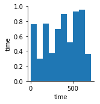

```python
# For Transcript df I will preview dataset, plot numeric variables and execute df_check function
display(transcript.head(5))
sns.pairplot(transcript);
display(df_check(transcript))
```

**Evanuation of the Profile data frame**

```python
# For Profile df I will preview dataset, plot numeric variables and execute df_check function
display(profile.head(5))
display(df_check(profile))
display(df_check(profile))
```

|  | age | became_member_on | gender | id | income |
| --- | --- | --- | --- | --- | --- |
| 0 | 118 | 20170212 | None | 68be06ca386d4c31939f3a4f0e3dd783 | NaN |
| 1 | 55 | 20170715 | F | 0610b486422d4921ae7d2bf64640c50b | 112000.0 |
| 2 | 118 | 20180712 | None | 38fe809add3b4fcf9315a9694bb96ff5 | NaN |
| 3 | 75 | 20170509 | F | 78afa995795e4d85b5d9ceeca43f5fef | 100000.0 |
| 4 | 118 | 20170804 | None | a03223e636434f42ac4c3df47e8bac43 | NaN |

```
number of rows in the dataframe: 17000
number of columns in the dataframe: 5

data types in dataframe
 age                   int64
became_member_on      int64
gender               object
id                   object
income              float64
dtype: object

Features : ['age', 'became_member_on', 'gender', 'id', 'income']


Null values :
 age                    0
became_member_on       0
gender              2175
id                     0
income              2175
dtype: int64


Basic statistics for numeric values:
                 age  became_member_on         income
count  17000.000000      1.700000e+04   14825.000000
mean      62.531412      2.016703e+07   65404.991568
std       26.738580      1.167750e+04   21598.299410
min       18.000000      2.013073e+07   30000.000000
25%       45.000000      2.016053e+07   49000.000000
50%       58.000000      2.017080e+07   64000.000000
75%       73.000000      2.017123e+07   80000.000000
max      118.000000      2.018073e+07  120000.000000
```

```
None
```

```
number of rows in the dataframe: 17000
number of columns in the dataframe: 5

data types in dataframe
 age                   int64
became_member_on      int64
gender               object
id                   object
income              float64
dtype: object

Features : ['age', 'became_member_on', 'gender', 'id', 'income']


Null values :
 age                    0
became_member_on       0
gender              2175
id                     0
income              2175
dtype: int64


Basic statistics for numeric values:
                 age  became_member_on         income
count  17000.000000      1.700000e+04   14825.000000
mean      62.531412      2.016703e+07   65404.991568
std       26.738580      1.167750e+04   21598.299410
min       18.000000      2.013073e+07   30000.000000
25%       45.000000      2.016053e+07   49000.000000
50%       58.000000      2.017080e+07   64000.000000
75%       73.000000      2.017123e+07   80000.000000
max      118.000000      2.018073e+07  120000.000000
```

```
None
```

**Evanuation of the Portfolio data frame**

|  | channels | difficulty | duration | id | offer_type | reward |
| --- | --- | --- | --- | --- | --- | --- |
| 0 | [email, mobile, social] | 10 | 7 | ae264e3637204a6fb9bb56bc8210ddfd | bogo | 10 |
| 1 | [web, email, mobile, social] | 10 | 5 | 4d5c57ea9a6940dd891ad53e9dbe8da0 | bogo | 10 |
| 2 | [web, email, mobile] | 0 | 4 | 3f207df678b143eea3cee63160fa8bed | informational | 0 |
| 3 | [web, email, mobile] | 5 | 7 | 9b98b8c7a33c4b65b9aebfe6a799e6d9 | bogo | 5 |
| 4 | [web, email] | 20 | 10 | 0b1e1539f2cc45b7b9fa7c272da2e1d7 | discount | 5 |

```
number of rows in the dataframe: 10
number of columns in the dataframe: 6

data types in dataframe
 channels      object
difficulty     int64
duration       int64
id            object
offer_type    object
reward         int64
dtype: object

Features : ['channels', 'difficulty', 'duration', 'id', 'offer_type', 'reward']


Null values :
 channels      0
difficulty    0
duration      0
id            0
offer_type    0
reward        0
dtype: int64


Basic statistics for numeric values:
        difficulty   duration     reward
count   10.000000  10.000000  10.000000
mean     7.700000   6.500000   4.200000
std      5.831905   2.321398   3.583915
min      0.000000   3.000000   0.000000
25%      5.000000   5.000000   2.000000
50%      8.500000   7.000000   4.000000
75%     10.000000   7.000000   5.000000
max     20.000000  10.000000  10.000000
```

```
None
```

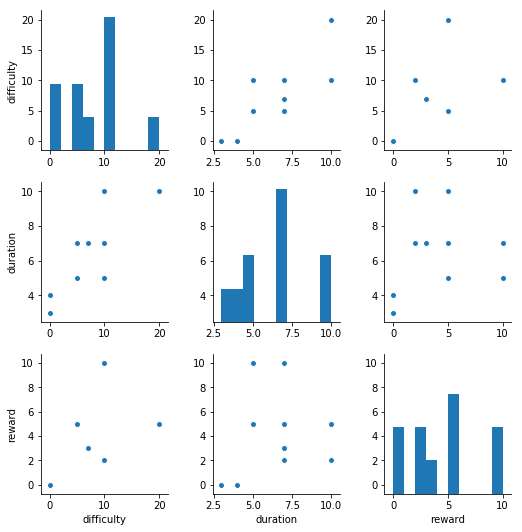

```python
# For Portfolio df I will preview dataset, plot numeric variables and execute df_check functio
display(portfolio.head(5))
sns.pairplot(portfolio);
display(df_check(portfolio))
```

## 3.3. Data Cleaning

In the data cleaning section I will describe quality and Tidiness issues found during the Accessing Data step. For each issue I will identify needed fix that will be implemented in this step.

Issues found during the data assesement step.

Quality issues:

- date is not stored as a date (profile df).
- age for customers is 118 years (profile df).

Tidiness issues:

- Channels are stored in one column (Portfolio df).
- Value column consists both type (like offer id name) and reference value (like true offer id) (Transcript df).
- Data is stored in 3 different data frames.

Following steps will be executed in this section:

1. Create copy of existing data frame.
2. Define solution and fix issue (for each identified issue).
3. Check if solution resolved the problem.
4. Create final data frame and asses it.

**Creation of the data frame copy**

```python
# I have created copy of each dataframe
portfolio_clean = portfolio.copy()
profile_clean = profile.copy()
transcript_clean = transcript.copy()
```

**Define solution and fix issue**

2.1. Quality issue: date is not stored as a date (profile df)

Solution: Reformat column to the date format

```python
# Reformat column to the date format
profile_clean.became_member_on = profile.became_member_on.apply(
    lambda x :datetime.strptime(str(x), '%Y%m%d').date())

# Check if issue is solved
display(profile_clean.head(5))
```

|  | age | became_member_on | gender | id | income |
| --- | --- | --- | --- | --- | --- |
| 0 | 118 | 2017-02-12 | None | 68be06ca386d4c31939f3a4f0e3dd783 | NaN |
| 1 | 55 | 2017-07-15 | F | 0610b486422d4921ae7d2bf64640c50b | 112000.0 |
| 2 | 118 | 2018-07-12 | None | 38fe809add3b4fcf9315a9694bb96ff5 | NaN |
| 3 | 75 | 2017-05-09 | F | 78afa995795e4d85b5d9ceeca43f5fef | 100000.0 |
| 4 | 118 | 2017-08-04 | None | a03223e636434f42ac4c3df47e8bac43 | NaN |

2.2. Tidiness issue: Channels are stored in one column (Portfolio df)

Solution: Represent each channel as a separate column.

```python
# Reformat channels column to separe column per channel
multilabbin = MultiLabelBinarizer()

transformed_column = portfolio.channels
portfolio_clean = portfolio.join(
    pd.DataFrame(
        multilabbin.fit_transform(transformed_column),
        columns=multilabbin.classes_,
        index=portfolio.index)).drop(['channels'], axis =1)

# Check if issue is solved
display(portfolio_clean)
```

|  | difficulty | duration | id | offer_type | reward | email | mobile | social | web |
| --- | --- | --- | --- | --- | --- | --- | --- | --- | --- |
| 0 | 10 | 7 | ae264e3637204a6fb9bb56bc8210ddfd | bogo | 10 | 1 | 1 | 1 | 0 |
| 1 | 10 | 5 | 4d5c57ea9a6940dd891ad53e9dbe8da0 | bogo | 10 | 1 | 1 | 1 | 1 |
| 2 | 0 | 4 | 3f207df678b143eea3cee63160fa8bed | informational | 0 | 1 | 1 | 0 | 1 |
| 3 | 5 | 7 | 9b98b8c7a33c4b65b9aebfe6a799e6d9 | bogo | 5 | 1 | 1 | 0 | 1 |
| 4 | 20 | 10 | 0b1e1539f2cc45b7b9fa7c272da2e1d7 | discount | 5 | 1 | 0 | 0 | 1 |
| 5 | 7 | 7 | 2298d6c36e964ae4a3e7e9706d1fb8c2 | discount | 3 | 1 | 1 | 1 | 1 |
| 6 | 10 | 10 | fafdcd668e3743c1bb461111dcafc2a4 | discount | 2 | 1 | 1 | 1 | 1 |
| 7 | 0 | 3 | 5a8bc65990b245e5a138643cd4eb9837 | informational | 0 | 1 | 1 | 1 | 0 |
| 8 | 5 | 5 | f19421c1d4aa40978ebb69ca19b0e20d | bogo | 5 | 1 | 1 | 1 | 1 |
| 9 | 10 | 7 | 2906b810c7d4411798c6938adc9daaa5 | discount | 2 | 1 | 1 | 0 | 1 |

2.3. Tidiness issue: Value column consists both type (like offer id name) and reference value (like true offer id) (Transcript df).

Solution: Re-format data to represent types in one column

```python
# Reformat transcript df
transcript_clean = transcript.join(
    pd.DataFrame(
        pd.io.json.json_normalize(transcript.value),
        index=transcript.index)).drop(['value'], axis =1)

# Rename column to eliminate confusing namings
transcript_clean = transcript_clean.rename(columns={
    "offer id" : "offer_id",
    "offer_id":"completed_offer_id",
    "reward":"reward_received"
})


# Fillna
transcript_clean.offer_id.fillna(transcript_clean.completed_offer_id, inplace=True)

# Check if issue is solved
display(transcript_clean.head(5))
```

|  | event | person | time | amount | offer_id | completed_offer_id | reward_received |
| --- | --- | --- | --- | --- | --- | --- | --- |
| 0 | offer received | 78afa995795e4d85b5d9ceeca43f5fef | 0 | NaN | 9b98b8c7a33c4b65b9aebfe6a799e6d9 | NaN | NaN |
| 1 | offer received | a03223e636434f42ac4c3df47e8bac43 | 0 | NaN | 0b1e1539f2cc45b7b9fa7c272da2e1d7 | NaN | NaN |
| 2 | offer received | e2127556f4f64592b11af22de27a7932 | 0 | NaN | 2906b810c7d4411798c6938adc9daaa5 | NaN | NaN |
| 3 | offer received | 8ec6ce2a7e7949b1bf142def7d0e0586 | 0 | NaN | fafdcd668e3743c1bb461111dcafc2a4 | NaN | NaN |
| 4 | offer received | 68617ca6246f4fbc85e91a2a49552598 | 0 | NaN | 4d5c57ea9a6940dd891ad53e9dbe8da0 | NaN | NaN |

2.4. Quality issue: age for customers is 118 years (profile df)

```python
#  check details about issue
df_c = profile_clean.query('age > 100')
df_c.groupby('age').count()
```

| age | became_member_on | gender | id | income |
| --- | --- | --- | --- | --- |
| 101 | 5 | 5 | 5 | 5 |
| 118 | 2175 | 0 | 2175 | 0 |

```python
# Calculate mean for values without 118
df_m = profile.query('age < 118')
df_m['age'].mean()
```

```
54.393524451939292
```

```python
# Replace 118 age with mean
profile_clean.age = profile_clean.age.replace(118,54)
```

```python
# Check if issue is solved.
df_g = profile_clean.query('age > 100')
df_g.groupby('age').count()
```

| age | became_member_on | gender | id | income |
| --- | --- | --- | --- | --- |
| 101 | 5 | 5 | 5 | 5 |

2.5. Tidiness issue: Data is stored in 3 different data frames.

Solution: Create one new dataframe

```python
# Left join transcript and profile, create temp dataframe
agg_tr_pr = pd.merge(transcript_clean, profile_clean, left_on="person", right_on="id", how='left').drop(["id"],axis=1)
```

```python
# Evaluate new dataframe
display(df_check(agg_tr_pr))
```

```
number of rows in the dataframe: 306534
number of columns in the dataframe: 11

data types in dataframe
 event                  object
person                 object
time                    int64
amount                float64
offer_id               object
completed_offer_id     object
reward_received       float64
age                     int64
became_member_on       object
gender                 object
income                float64
dtype: object

Features : ['event', 'person', 'time', 'amount', 'offer_id', 'completed_offer_id', 'reward_received', 'age', 'became_member_on', 'gender', 'income']


Null values :
 event                      0
person                     0
time                       0
amount                167581
offer_id              138953
completed_offer_id    272955
reward_received       272955
age                        0
became_member_on           0
gender                 33772
income                 33772
dtype: int64


Basic statistics for numeric values:
                 time         amount  reward_received            age  \
count  306534.000000  138953.000000     33579.000000  306534.000000
mean      366.382940      12.777356         4.904137      53.858247
std       200.326314      30.250529         2.886647      16.556353
min         0.000000       0.050000         2.000000      18.000000
25%       186.000000       2.780000         2.000000      43.000000
50%       408.000000       8.890000         5.000000      54.000000
75%       528.000000      18.070000         5.000000      64.000000
max       714.000000    1062.280000        10.000000     101.000000

              income
count  272762.000000
mean    64337.000755
std     21243.762941
min     30000.000000
25%     48000.000000
50%     62000.000000
75%     78000.000000
max    120000.000000
```

```
None
```

```python
# Evaluate new dataframe
agg_tr_pr.head()
```

|  | event | person | time | amount | offer_id | completed_offer_id | reward_received | age | became_member_on | gender | income |
| --- | --- | --- | --- | --- | --- | --- | --- | --- | --- | --- | --- |
| 0 | offer received | 78afa995795e4d85b5d9ceeca43f5fef | 0 | NaN | 9b98b8c7a33c4b65b9aebfe6a799e6d9 | NaN | NaN | 75 | 2017-05-09 | F | 100000.0 |
| 1 | offer received | a03223e636434f42ac4c3df47e8bac43 | 0 | NaN | 0b1e1539f2cc45b7b9fa7c272da2e1d7 | NaN | NaN | 54 | 2017-08-04 | None | NaN |
| 2 | offer received | e2127556f4f64592b11af22de27a7932 | 0 | NaN | 2906b810c7d4411798c6938adc9daaa5 | NaN | NaN | 68 | 2018-04-26 | M | 70000.0 |
| 3 | offer received | 8ec6ce2a7e7949b1bf142def7d0e0586 | 0 | NaN | fafdcd668e3743c1bb461111dcafc2a4 | NaN | NaN | 54 | 2017-09-25 | None | NaN |
| 4 | offer received | 68617ca6246f4fbc85e91a2a49552598 | 0 | NaN | 4d5c57ea9a6940dd891ad53e9dbe8da0 | NaN | NaN | 54 | 2017-10-02 | None | NaN |

```python
# Left join agg and portfolio
final_df = pd.merge(agg_tr_pr,portfolio_clean, left_on="offer_id", right_on="id", how='left').drop(["id"],axis=1)
```

**Creation of the final data frame and the assesement of it**

```python
# Evaluate new dataframe
display(df_check(final_df))
```

```
number of rows in the dataframe: 306534
number of columns in the dataframe: 19

data types in dataframe
 event                  object
person                 object
time                    int64
amount                float64
offer_id               object
completed_offer_id     object
reward_received       float64
age                     int64
became_member_on       object
gender                 object
income                float64
difficulty            float64
duration              float64
offer_type             object
reward                float64
email                 float64
mobile                float64
social                float64
web                   float64
dtype: object

Features : ['event', 'person', 'time', 'amount', 'offer_id', 'completed_offer_id', 'reward_received', 'age', 'became_member_on', 'gender', 'income', 'difficulty', 'duration', 'offer_type', 'reward', 'email', 'mobile', 'social', 'web']


Null values :
 event                      0
person                     0
time                       0
amount                167581
offer_id              138953
completed_offer_id    272955
reward_received       272955
age                        0
became_member_on           0
gender                 33772
income                 33772
```

[output cut: 26 more lines]

```
min     30000.000000       0.000000       3.000000       0.00000       1.0
25%     48000.000000       5.000000       5.000000       2.00000       1.0
50%     62000.000000      10.000000       7.000000       5.00000       1.0
75%     78000.000000      10.000000       7.000000       5.00000       1.0
max    120000.000000      20.000000      10.000000      10.00000       1.0

              mobile         social            web
count  167581.000000  167581.000000  167581.000000
mean        0.917944       0.656996       0.806858
std         0.274451       0.474714       0.394765
min         0.000000       0.000000       0.000000
25%         1.000000       0.000000       1.000000
50%         1.000000       1.000000       1.000000
75%         1.000000       1.000000       1.000000
max         1.000000       1.000000       1.000000
```

```
None
```

```python
# Evaluate new dataframe
final_df.head()
```

|  | event | person | time | amount | offer_id | completed_offer_id | reward_received | age | became_member_on | gender | income | difficulty | duration | offer_type | reward | email | mobile | social | web |
| --- | --- | --- | --- | --- | --- | --- | --- | --- | --- | --- | --- | --- | --- | --- | --- | --- | --- | --- | --- |
| 0 | offer received | 78afa995795e4d85b5d9ceeca43f5fef | 0 | NaN | 9b98b8c7a33c4b65b9aebfe6a799e6d9 | NaN | NaN | 75 | 2017-05-09 | F | 100000.0 | 5.0 | 7.0 | bogo | 5.0 | 1.0 | 1.0 | 0.0 | 1.0 |
| 1 | offer received | a03223e636434f42ac4c3df47e8bac43 | 0 | NaN | 0b1e1539f2cc45b7b9fa7c272da2e1d7 | NaN | NaN | 54 | 2017-08-04 | None | NaN | 20.0 | 10.0 | discount | 5.0 | 1.0 | 0.0 | 0.0 | 1.0 |
| 2 | offer received | e2127556f4f64592b11af22de27a7932 | 0 | NaN | 2906b810c7d4411798c6938adc9daaa5 | NaN | NaN | 68 | 2018-04-26 | M | 70000.0 | 10.0 | 7.0 | discount | 2.0 | 1.0 | 1.0 | 0.0 | 1.0 |
| 3 | offer received | 8ec6ce2a7e7949b1bf142def7d0e0586 | 0 | NaN | fafdcd668e3743c1bb461111dcafc2a4 | NaN | NaN | 54 | 2017-09-25 | None | NaN | 10.0 | 10.0 | discount | 2.0 | 1.0 | 1.0 | 1.0 | 1.0 |
| 4 | offer received | 68617ca6246f4fbc85e91a2a49552598 | 0 | NaN | 4d5c57ea9a6940dd891ad53e9dbe8da0 | NaN | NaN | 54 | 2017-10-02 | None | NaN | 10.0 | 5.0 | bogo | 10.0 | 1.0 | 1.0 | 1.0 | 1.0 |

```python
# Create new dataframe
datadf = final_df.copy()
```

```python
# Check nulls for income
datadf.income.isnull().sum()
```

```
33772
```

```python
# Income - fill nulls with mode
datadf.income.fillna(final_df['income'].mode()[0], inplace=True)
```

```python
#Check solution
datadf.income.isnull().sum()
```

```
0
```

As an outcome of this step I have created datadf dataframe.

# 4. Data Enriching

In this section I will enrich data with new features like aggregations dataframe or like new fields like ratings so these can be later used in clustering.

To aggregate data following new columns in the dataframe will be created:

1. Total item by event types (promotion viewed, completed, etc.)
2. Total and average of amount spend and rewards received
3. Total and rate of events by promotions type, difficulty, duration, and reward
4. Total and rate of events by promotion channel

In the first step I will create functions that support operations and then execute aggregations.

**Functions**

```python
# Data Enriching - create functions to generate rate of promotion completion (promotion completed/ promotion received)

####
#    Creates aggregate value based on 'events' column
#
#    INPUT: transaction item
#
#    OUTPUT: total value
#
#####

def sum_offer_received(trx):
    return np.sum(trx=="offer received")
def sum_offer_viewed(trx):
    return np.sum(trx=="offer viewed")
def sum_offer_completed(trx):
    return np.sum(trx=="offer completed")
def sum_transaction(trx):
    return np.sum(trx=="transaction")

####
#    Creates rate of promotion completion by promotion type
#
#    INPUT:
#        dfsource : raw trx dataframe
#        anchor : groupby indicator
#        var: type of variation
#       dftotal : master table to collect total number of trx
#        dfrate : master table to collect rate
#
#   OUTPUT: merged table of total value
#
####

def rating_generator1(dfsource,anchor,var,dftotal,dfrate) :
    if(not isinstance(dfsource[var][1], str)) :
        dfsource[var].fillna(0,inplace=True)
        dfsource[var]= dfsource[var].astype(int).astype(str)

    df= dfsource.groupby([anchor, var]).agg({
        'event':[sum_offer_received,sum_offer_completed],
            })
    df.columns = ["_".join(x) for x in df.columns.ravel()]
    df = df.unstack()
    df.columns = ["_".join(x)+"_"+var for x in df.columns.ravel()]

    dftemp = pd.merge(dftotal, df, on="person", how='left')

    type = dfsource[var].value_counts().index
    if(not isinstance(dfsource[var][1], str)) : type= type.astype(int).astype(str)

    for i in type :
        col_name = var+'_rate_'+i
        completed = 'event_sum_offer_completed_'+i+"_"+var
        received = 'event_sum_offer_received_'+i+"_"+var
        dfrate[col_name] = df[completed]/df[received]
    print(var," completed")
    return dftemp

####
#    Creates rate of promotion completion by promotion type
#
#    INPUT:
#        dfsource : raw trx dataframe
#        anchor : groupby indicator
#        var: type of variation
#        dftotal : master table to collect total number of trx
#        dfrate : master table to collect rate
#
#    OUTPUT: merged table of total value
####

def rating_generator2(dfsource,anchor,var,dftotal,dfrate):
    df= dfsource[dfsource[var]==1].groupby([anchor]).agg({
        'event':[sum_offer_received,sum_offer_completed],
            })
    df.columns = ["_".join(x)+"_"+var for x in df.columns.ravel()]
    dftemp = pd.merge(dftotal, df, on="person", how='left')

    col_name = var+'_rate'
    completed = 'event_sum_offer_completed_'+var
    received = 'event_sum_offer_received_'+var
    dfrate[col_name] = df[completed]/df[received]
    print(var," completed")
    return dftemp
```

**Aggregations**

```python
# create new df for operations
dfsource = datadf.copy()
dfrate = pd.DataFrame()
```

```python
# create aggregations on the person level
dftotal = dfsource.groupby(['person']).agg({
    'event': [sum_offer_received,sum_offer_viewed,sum_offer_completed,sum_transaction],
    'reward_received' :[nansum,nanmean],
    'amount' :[nansum,nanmean]
})
dftotal.columns = ["_".join(x) for x in dftotal.columns.ravel()]
dftotal['completed_rate'] = dftotal['event_sum_offer_completed']/dftotal['event_sum_offer_received']

display(dftotal.head(5))
```

| person | event_sum_offer_received | event_sum_offer_viewed | event_sum_offer_completed | event_sum_transaction | reward_received_nansum | reward_received_nanmean | amount_nansum | amount_nanmean | completed_rate |
| --- | --- | --- | --- | --- | --- | --- | --- | --- | --- |
| 0009655768c64bdeb2e877511632db8f | 5 | 4 | 3 | 8 | 9.0 | 3.000000 | 127.60 | 15.950000 | 0.60 |
| 00116118485d4dfda04fdbaba9a87b5c | 2 | 2 | 0 | 3 | 0.0 | NaN | 4.09 | 1.363333 | 0.00 |
| 0011e0d4e6b944f998e987f904e8c1e5 | 5 | 5 | 3 | 5 | 13.0 | 4.333333 | 79.46 | 15.892000 | 0.60 |
| 0020c2b971eb4e9188eac86d93036a77 | 5 | 3 | 3 | 8 | 14.0 | 4.666667 | 196.86 | 24.607500 | 0.60 |
| 0020ccbbb6d84e358d3414a3ff76cffd | 4 | 4 | 3 | 12 | 13.0 | 4.333333 | 154.05 | 12.837500 | 0.75 |

In the next step I will create rating for each user. This will help to understand which promo was the best for particular customer.

**Ratings**

```python
# rating for each users generation
rate_category = ['offer_type','reward','difficulty','duration']
rate_channel = ['mobile','web','email','social']
anchor = 'person'

for var in rate_category :
    dftotal = rating_generator1(dfsource,anchor,var,dftotal,dfrate)

for var in rate_channel :
    dftotal = rating_generator2(dfsource,anchor,var,dftotal,dfrate)

dffinal = pd.merge(dftotal, dfrate, on="person", how='left')
```

```
offer_type  completed
reward  completed
difficulty  completed
duration  completed
mobile  completed
web  completed
email  completed
social  completed
```

```python
# View output of ratings
display(dftotal.head(5))
display(dftotal.describe())
display(dfrate.head(5))
display(dfrate.describe())
display(dffinal.head(5))
display(dffinal.describe())
```

| person | event_sum_offer_received | event_sum_offer_viewed | event_sum_offer_completed | event_sum_transaction | reward_received_nansum | reward_received_nanmean | amount_nansum | amount_nanmean | completed_rate | event_sum_offer_received_bogo_offer_type | ... | event_sum_offer_completed_5_duration | event_sum_offer_completed_7_duration | event_sum_offer_received_mobile | event_sum_offer_completed_mobile | event_sum_offer_received_web | event_sum_offer_completed_web | event_sum_offer_received_email | event_sum_offer_completed_email | event_sum_offer_received_social | event_sum_offer_completed_social |
| --- | --- | --- | --- | --- | --- | --- | --- | --- | --- | --- | --- | --- | --- | --- | --- | --- | --- | --- | --- | --- | --- |
| 0009655768c64bdeb2e877511632db8f | 5 | 4 | 3 | 8 | 9.0 | 3.000000 | 127.60 | 15.950000 | 0.60 | 1.0 | ... | 1.0 | 1.0 | 5.0 | 3.0 | 4.0 | 3.0 | 5.0 | 3.0 | 3.0 | 2.0 |
| 00116118485d4dfda04fdbaba9a87b5c | 2 | 2 | 0 | 3 | 0.0 | NaN | 4.09 | 1.363333 | 0.00 | 2.0 | ... | 0.0 | NaN | 2.0 | 0.0 | 2.0 | 0.0 | 2.0 | 0.0 | 2.0 | 0.0 |
| 0011e0d4e6b944f998e987f904e8c1e5 | 5 | 5 | 3 | 5 | 13.0 | 4.333333 | 79.46 | 15.892000 | 0.60 | 1.0 | ... | NaN | 2.0 | 4.0 | 2.0 | 4.0 | 3.0 | 5.0 | 3.0 | 2.0 | 1.0 |
| 0020c2b971eb4e9188eac86d93036a77 | 5 | 3 | 3 | 8 | 14.0 | 4.666667 | 196.86 | 24.607500 | 0.60 | 2.0 | ... | 1.0 | 0.0 | 5.0 | 3.0 | 3.0 | 3.0 | 5.0 | 3.0 | 5.0 | 3.0 |
| 0020ccbbb6d84e358d3414a3ff76cffd | 4 | 4 | 3 | 12 | 13.0 | 4.333333 | 154.05 | 12.837500 | 0.75 | 2.0 | ... | 1.0 | 2.0 | 4.0 | 3.0 | 3.0 | 3.0 | 4.0 | 3.0 | 3.0 | 2.0 |

5 rows × 55 columns

|  | event_sum_offer_received | event_sum_offer_viewed | event_sum_offer_completed | event_sum_transaction | reward_received_nansum | reward_received_nanmean | amount_nansum | amount_nanmean | completed_rate | event_sum_offer_received_bogo_offer_type | ... | event_sum_offer_completed_5_duration | event_sum_offer_completed_7_duration | event_sum_offer_received_mobile | event_sum_offer_completed_mobile | event_sum_offer_received_web | event_sum_offer_completed_web | event_sum_offer_received_email | event_sum_offer_completed_email | event_sum_offer_received_social | event_sum_offer_completed_social |
| --- | --- | --- | --- | --- | --- | --- | --- | --- | --- | --- | --- | --- | --- | --- | --- | --- | --- | --- | --- | --- | --- |
| count | 17000.000000 | 17000.000000 | 17000.000000 | 17000.000000 | 17000.000000 | 12774.000000 | 17000.000000 | 16578.000000 | 16994.000000 | 14992.000000 | ... | 10570.000000 | 14969.000000 | 16980.000000 | 16980.000000 | 16916.000000 | 16916.000000 | 16994.000000 | 16994.000000 | 16529.000000 | 16529.000000 |
| mean | 4.486882 | 3.395588 | 1.975235 | 8.173706 | 9.686824 | 4.753841 | 104.438351 | 13.680266 | 0.439952 | 2.034352 | ... | 0.721570 | 1.150043 | 4.040577 | 1.776148 | 3.606113 | 1.767025 | 4.488467 | 1.975933 | 2.763809 | 1.318168 |
| std | 1.076165 | 1.297653 | 1.605563 | 5.116250 | 9.243217 | 1.995253 | 125.922619 | 16.056763 | 0.339395 | 0.966841 | ... | 0.768476 | 1.066627 | 1.157563 | 1.476880 | 1.189135 | 1.474161 | 1.073047 | 1.605417 | 1.148938 | 1.218399 |
| min | 0.000000 | 0.000000 | 0.000000 | 0.000000 | 0.000000 | 2.000000 | 0.000000 | 0.050000 | 0.000000 | 1.000000 | ... | 0.000000 | 0.000000 | 1.000000 | 0.000000 | 1.000000 | 0.000000 | 1.000000 | 0.000000 | 1.000000 | 0.000000 |
| 25% | 4.000000 | 2.750000 | 1.000000 | 4.000000 | 2.000000 | 3.200000 | 21.820000 | 3.181392 | 0.166667 | 1.000000 | ... | 0.000000 | 0.000000 | 3.000000 | 0.000000 | 3.000000 | 0.000000 | 4.000000 | 1.000000 | 2.000000 | 0.000000 |
| 50% | 5.000000 | 3.000000 | 2.000000 | 7.000000 | 7.000000 | 4.750000 | 69.405000 | 11.996607 | 0.500000 | 2.000000 | ... | 1.000000 | 1.000000 | 4.000000 | 2.000000 | 4.000000 | 2.000000 | 5.000000 | 2.000000 | 3.000000 | 1.000000 |
| 75% | 5.000000 | 4.000000 | 3.000000 | 11.000000 | 15.000000 | 6.000000 | 148.782500 | 20.469643 | 0.750000 | 3.000000 | ... | 1.000000 | 2.000000 | 5.000000 | 3.000000 | 4.000000 | 3.000000 | 5.000000 | 3.000000 | 4.000000 | 2.000000 |
| max | 6.000000 | 6.000000 | 6.000000 | 36.000000 | 55.000000 | 10.000000 | 1608.690000 | 451.470000 | 1.000000 | 6.000000 | ... | 5.000000 | 6.000000 | 6.000000 | 6.000000 | 6.000000 | 6.000000 | 6.000000 | 6.000000 | 6.000000 | 6.000000 |

8 rows × 55 columns

| person | offer_type_rate_bogo | offer_type_rate_discount | offer_type_rate_informational | reward_rate_0 | reward_rate_5 | reward_rate_10 | reward_rate_2 | reward_rate_3 | difficulty_rate_0 | difficulty_rate_10 | ... | duration_rate_0 | duration_rate_7 | duration_rate_5 | duration_rate_10 | duration_rate_3 | duration_rate_4 | mobile_rate | web_rate | email_rate | social_rate |
| --- | --- | --- | --- | --- | --- | --- | --- | --- | --- | --- | --- | --- | --- | --- | --- | --- | --- | --- | --- | --- | --- |
| 0009655768c64bdeb2e877511632db8f | 1.0 | 1.0 | 0.0 | 0.0 | 1.0 | NaN | 1.0 | NaN | 0.0 | 1.00 | ... | NaN | 1.0 | 1.0 | 1.0 | 0.0 | 0.0 | 0.60 | 0.75 | 0.60 | 0.666667 |
| 00116118485d4dfda04fdbaba9a87b5c | 0.0 | NaN | NaN | NaN | 0.0 | NaN | NaN | NaN | NaN | NaN | ... | NaN | NaN | 0.0 | NaN | NaN | NaN | 0.00 | 0.00 | 0.00 | 0.000000 |
| 0011e0d4e6b944f998e987f904e8c1e5 | 1.0 | 1.0 | 0.0 | 0.0 | 1.0 | NaN | NaN | 1.0 | 0.0 | NaN | ... | NaN | 1.0 | NaN | 1.0 | 0.0 | 0.0 | 0.50 | 0.75 | 0.60 | 0.500000 |
| 0020c2b971eb4e9188eac86d93036a77 | 0.5 | 1.0 | 0.0 | 0.0 | NaN | 0.5 | 1.0 | NaN | 0.0 | 0.75 | ... | NaN | 0.0 | 1.0 | 1.0 | 0.0 | NaN | 0.60 | 1.00 | 0.60 | 0.600000 |
| 0020ccbbb6d84e358d3414a3ff76cffd | 1.0 | 1.0 | 0.0 | 0.0 | 1.0 | NaN | NaN | 1.0 | 0.0 | NaN | ... | NaN | 1.0 | 1.0 | NaN | 0.0 | NaN | 0.75 | 1.00 | 0.75 | 0.666667 |

5 rows × 23 columns

|  | offer_type_rate_bogo | offer_type_rate_discount | offer_type_rate_informational | reward_rate_0 | reward_rate_5 | reward_rate_10 | reward_rate_2 | reward_rate_3 | difficulty_rate_0 | difficulty_rate_10 | ... | duration_rate_0 | duration_rate_7 | duration_rate_5 | duration_rate_10 | duration_rate_3 | duration_rate_4 | mobile_rate | web_rate | email_rate | social_rate |
| --- | --- | --- | --- | --- | --- | --- | --- | --- | --- | --- | --- | --- | --- | --- | --- | --- | --- | --- | --- | --- | --- |
| count | 14992.000000 | 14945.000000 | 10547.0 | 10547.0 | 13326.000000 | 10586.000000 | 10482.000000 | 6325.000000 | 10547.0 | 14925.000000 | ... | 0.0 | 14969.000000 | 10570.000000 | 10598.000000 | 6320.0 | 6331.0 | 16980.000000 | 16916.000000 | 16994.000000 | 16529.000000 |
| mean | 0.512479 | 0.585151 | 0.0 | 0.0 | 0.526149 | 0.456507 | 0.613832 | 0.676864 | 0.0 | 0.535945 | ... | NaN | 0.563902 | 0.503021 | 0.571155 | 0.0 | 0.0 | 0.439888 | 0.490475 | 0.439952 | 0.475931 |
| std | 0.447900 | 0.440070 | 0.0 | 0.0 | 0.458239 | 0.478986 | 0.461948 | 0.456098 | 0.0 | 0.447828 | ... | NaN | 0.440776 | 0.474528 | 0.471083 | 0.0 | 0.0 | 0.342839 | 0.373705 | 0.339395 | 0.393986 |
| min | 0.000000 | 0.000000 | 0.0 | 0.0 | 0.000000 | 0.000000 | 0.000000 | 0.000000 | 0.0 | 0.000000 | ... | NaN | 0.000000 | 0.000000 | 0.000000 | 0.0 | 0.0 | 0.000000 | 0.000000 | 0.000000 | 0.000000 |
| 25% | 0.000000 | 0.000000 | 0.0 | 0.0 | 0.000000 | 0.000000 | 0.000000 | 0.000000 | 0.0 | 0.000000 | ... | NaN | 0.000000 | 0.000000 | 0.000000 | 0.0 | 0.0 | 0.000000 | 0.000000 | 0.166667 | 0.000000 |
| 50% | 0.500000 | 0.666667 | 0.0 | 0.0 | 0.500000 | 0.000000 | 1.000000 | 1.000000 | 0.0 | 0.500000 | ... | NaN | 0.666667 | 0.500000 | 1.000000 | 0.0 | 0.0 | 0.500000 | 0.500000 | 0.500000 | 0.500000 |
| 75% | 1.000000 | 1.000000 | 0.0 | 0.0 | 1.000000 | 1.000000 | 1.000000 | 1.000000 | 0.0 | 1.000000 | ... | NaN | 1.000000 | 1.000000 | 1.000000 | 0.0 | 0.0 | 0.750000 | 0.800000 | 0.750000 | 1.000000 |
| max | 1.000000 | 1.000000 | 0.0 | 0.0 | 1.000000 | 1.000000 | 1.000000 | 1.000000 | 0.0 | 1.000000 | ... | NaN | 1.000000 | 1.000000 | 1.000000 | 0.0 | 0.0 | 1.000000 | 1.000000 | 1.000000 | 1.000000 |

8 rows × 23 columns

| person | event_sum_offer_received | event_sum_offer_viewed | event_sum_offer_completed | event_sum_transaction | reward_received_nansum | reward_received_nanmean | amount_nansum | amount_nanmean | completed_rate | event_sum_offer_received_bogo_offer_type | ... | duration_rate_0 | duration_rate_7 | duration_rate_5 | duration_rate_10 | duration_rate_3 | duration_rate_4 | mobile_rate | web_rate | email_rate | social_rate |
| --- | --- | --- | --- | --- | --- | --- | --- | --- | --- | --- | --- | --- | --- | --- | --- | --- | --- | --- | --- | --- | --- |
| 0009655768c64bdeb2e877511632db8f | 5 | 4 | 3 | 8 | 9.0 | 3.000000 | 127.60 | 15.950000 | 0.60 | 1.0 | ... | NaN | 1.0 | 1.0 | 1.0 | 0.0 | 0.0 | 0.60 | 0.75 | 0.60 | 0.666667 |
| 00116118485d4dfda04fdbaba9a87b5c | 2 | 2 | 0 | 3 | 0.0 | NaN | 4.09 | 1.363333 | 0.00 | 2.0 | ... | NaN | NaN | 0.0 | NaN | NaN | NaN | 0.00 | 0.00 | 0.00 | 0.000000 |
| 0011e0d4e6b944f998e987f904e8c1e5 | 5 | 5 | 3 | 5 | 13.0 | 4.333333 | 79.46 | 15.892000 | 0.60 | 1.0 | ... | NaN | 1.0 | NaN | 1.0 | 0.0 | 0.0 | 0.50 | 0.75 | 0.60 | 0.500000 |
| 0020c2b971eb4e9188eac86d93036a77 | 5 | 3 | 3 | 8 | 14.0 | 4.666667 | 196.86 | 24.607500 | 0.60 | 2.0 | ... | NaN | 0.0 | 1.0 | 1.0 | 0.0 | NaN | 0.60 | 1.00 | 0.60 | 0.600000 |
| 0020ccbbb6d84e358d3414a3ff76cffd | 4 | 4 | 3 | 12 | 13.0 | 4.333333 | 154.05 | 12.837500 | 0.75 | 2.0 | ... | NaN | 1.0 | 1.0 | NaN | 0.0 | NaN | 0.75 | 1.00 | 0.75 | 0.666667 |

5 rows × 78 columns

|  | event_sum_offer_received | event_sum_offer_viewed | event_sum_offer_completed | event_sum_transaction | reward_received_nansum | reward_received_nanmean | amount_nansum | amount_nanmean | completed_rate | event_sum_offer_received_bogo_offer_type | ... | duration_rate_0 | duration_rate_7 | duration_rate_5 | duration_rate_10 | duration_rate_3 | duration_rate_4 | mobile_rate | web_rate | email_rate | social_rate |
| --- | --- | --- | --- | --- | --- | --- | --- | --- | --- | --- | --- | --- | --- | --- | --- | --- | --- | --- | --- | --- | --- |
| count | 17000.000000 | 17000.000000 | 17000.000000 | 17000.000000 | 17000.000000 | 12774.000000 | 17000.000000 | 16578.000000 | 16994.000000 | 14992.000000 | ... | 0.0 | 14969.000000 | 10570.000000 | 10598.000000 | 6320.0 | 6331.0 | 16980.000000 | 16916.000000 | 16994.000000 | 16529.000000 |
| mean | 4.486882 | 3.395588 | 1.975235 | 8.173706 | 9.686824 | 4.753841 | 104.438351 | 13.680266 | 0.439952 | 2.034352 | ... | NaN | 0.563902 | 0.503021 | 0.571155 | 0.0 | 0.0 | 0.439888 | 0.490475 | 0.439952 | 0.475931 |
| std | 1.076165 | 1.297653 | 1.605563 | 5.116250 | 9.243217 | 1.995253 | 125.922619 | 16.056763 | 0.339395 | 0.966841 | ... | NaN | 0.440776 | 0.474528 | 0.471083 | 0.0 | 0.0 | 0.342839 | 0.373705 | 0.339395 | 0.393986 |
| min | 0.000000 | 0.000000 | 0.000000 | 0.000000 | 0.000000 | 2.000000 | 0.000000 | 0.050000 | 0.000000 | 1.000000 | ... | NaN | 0.000000 | 0.000000 | 0.000000 | 0.0 | 0.0 | 0.000000 | 0.000000 | 0.000000 | 0.000000 |
| 25% | 4.000000 | 2.750000 | 1.000000 | 4.000000 | 2.000000 | 3.200000 | 21.820000 | 3.181392 | 0.166667 | 1.000000 | ... | NaN | 0.000000 | 0.000000 | 0.000000 | 0.0 | 0.0 | 0.000000 | 0.000000 | 0.166667 | 0.000000 |
| 50% | 5.000000 | 3.000000 | 2.000000 | 7.000000 | 7.000000 | 4.750000 | 69.405000 | 11.996607 | 0.500000 | 2.000000 | ... | NaN | 0.666667 | 0.500000 | 1.000000 | 0.0 | 0.0 | 0.500000 | 0.500000 | 0.500000 | 0.500000 |
| 75% | 5.000000 | 4.000000 | 3.000000 | 11.000000 | 15.000000 | 6.000000 | 148.782500 | 20.469643 | 0.750000 | 3.000000 | ... | NaN | 1.000000 | 1.000000 | 1.000000 | 0.0 | 0.0 | 0.750000 | 0.800000 | 0.750000 | 1.000000 |
| max | 6.000000 | 6.000000 | 6.000000 | 36.000000 | 55.000000 | 10.000000 | 1608.690000 | 451.470000 | 1.000000 | 6.000000 | ... | NaN | 1.000000 | 1.000000 | 1.000000 | 0.0 | 0.0 | 1.000000 | 1.000000 | 1.000000 | 1.000000 |

8 rows × 78 columns

**Adding demographic data and tidiness aligment**

```python
# Add demographic data
demography=["person","age","gender","income"]
dfdemography = datadf[demography].drop_duplicates(subset=None, keep='first', inplace=False)
dffinal_test = pd.merge(dffinal, dfdemography, on="person", how='left')
```

```python
#  Encode multilevel columns for gender
multilevel_encoded = pd.get_dummies(dffinal_test.gender,prefix='gender')
print(multilevel_encoded.count())
multilevel_encoded.head(5)
dffinal_temp = pd.concat([dffinal_test,multilevel_encoded],axis=1)
dffinal_temp = dffinal_temp.drop(['gender'],axis=1)
```

```
gender_F    17000
gender_M    17000
gender_O    17000
dtype: int64
```

```python
# Set person as index
dffinal_temp = dffinal_temp.set_index(['person'])
dffinal_temp.head(1)
```

| person | event_sum_offer_received | event_sum_offer_viewed | event_sum_offer_completed | event_sum_transaction | reward_received_nansum | reward_received_nanmean | amount_nansum | amount_nanmean | completed_rate | event_sum_offer_received_bogo_offer_type | ... | duration_rate_4 | mobile_rate | web_rate | email_rate | social_rate | age | income | gender_F | gender_M | gender_O |
| --- | --- | --- | --- | --- | --- | --- | --- | --- | --- | --- | --- | --- | --- | --- | --- | --- | --- | --- | --- | --- | --- |
| 0009655768c64bdeb2e877511632db8f | 5 | 4 | 3 | 8 | 9.0 | 3.0 | 127.6 | 15.95 | 0.6 | 1.0 | ... | 0.0 | 0.6 | 0.75 | 0.6 | 0.666667 | 33 | 72000.0 | 0 | 1 | 0 |

1 rows × 83 columns

```python
# Finally, replance NaN with 0
```

```python
dffinal_temp = dffinal_temp.fillna(0)
```

# 5. Parameters selection for clustering

In this section I process data to determine optimal parameters for the clustering.

As a first I will scale data so it will not create issue later. RobustScaler will be used.

```python
# Apply feature scaling to the general population demographics data.
rc = RobustScaler()
dffinal_scaled = rc.fit_transform(dffinal_temp)
```

Secondly, I will apply PCA in order to improve performance.

```python
# Define function for PCA

# Investigate the variance accounted for by each principal component.
def screen_plot(pca):
    '''
    Creates a scree plot associated with the principal components

    INPUT: pca - the result of instantian of PCA in scikit learn

    OUTPUT:
            None
    '''
    num_components = len(pca.explained_variance_ratio_)
    ind = np.arange(num_components)
    vals = pca.explained_variance_ratio_

    plt.figure(figsize=(10, 6))
    ax = plt.subplot(111)
    cumvals = np.cumsum(vals)
    ax.bar(ind, vals)
    ax.plot(ind, cumvals)
    for i in range(num_components):
        ax.annotate(r"%s%%" % ((str(vals[i]*100)[:4])), (ind[i]+0.2, vals[i]), va="bottom", ha="center", fontsize=12)

    ax.xaxis.set_tick_params(width=0)
    ax.yaxis.set_tick_params(width=2, length=12)

    ax.set_xlabel("Principal Component")
    ax.set_ylabel("Variance Explained (%)")
    plt.title('Explained Variance Per Principal Component')
```

```python
# Apply PCA
pca_50 = PCA(n_components=50)
dffinal_pca_50 = pca_50.fit_transform(dffinal_scaled)
pca_30 = PCA(n_components=30)
dffinal_pca_30  = pca_30.fit_transform(dffinal_scaled)
pca_20 = PCA(n_components=20)
dffinal_pca_20  = pca_20.fit_transform(dffinal_scaled)
pca_15 = PCA(n_components=15)
dffinal_pca_15 = pca_15.fit_transform(dffinal_scaled)
pca_10 = PCA(n_components=10)
dffinal_pca_10 = pca_10.fit_transform(dffinal_scaled)
pca_5 = PCA(n_components=5)
dffinal_pca_5 = pca_5.fit_transform(dffinal_scaled)
```

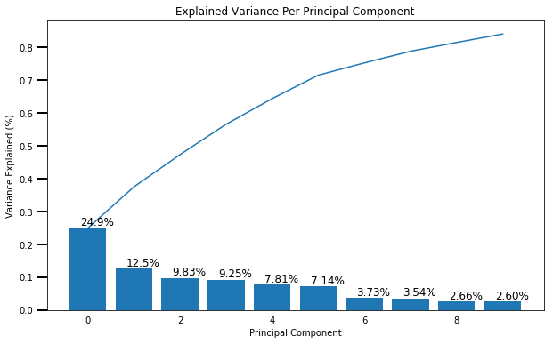

```python
# plot PCA, for the purpose of this workbook I have narrowed plot only to 1 value but it can be run on each value
screen_plot(pca_10)
```

```python
x = dffinal_pca_10
```

A fundamental step for any unsupervised algorithm is to determine the optimal number of clusters into which the data may be clustered. The Elbow Method is one of the most popular methods to determine this optimal value of k. In the next step I will use Elbow method to determine number of clusters.

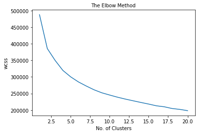

```python
# running and plotting Elbow Method
wcss = []
for i in range(1,21):
    km = KMeans(n_clusters = i, init = 'k-means++', max_iter =300, n_init =10, random_state = 42)
    km.fit(x)
    wcss.append(km.inertia_)

plt.plot(range(1,21), wcss)
plt.title('The Elbow Method', fontsize = 10)
plt.xlabel('No. of Clusters')
plt.ylabel('wcss')
plt.show()
```

To determine the optimal number of clusters, we have to select the value of k at the “elbow” ie the point after which the distortion/inertia start decreasing in a linear fashion. Currently, this point is hard to catch, but linelar trends seems to be seen since 10 for sure, therefore I will reduce number of clusters to 10.

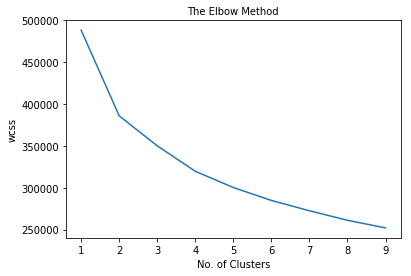

```python
# running and plotting Elbow Method
wcss = []
for i in range(1,10):
    km = KMeans(n_clusters = i, init = 'k-means++', max_iter =300, n_init =10, random_state = 42)
    km.fit(x)
    wcss.append(km.inertia_)

plt.plot(range(1,10), wcss)
plt.title('The Elbow Method', fontsize = 10)
plt.xlabel('No. of Clusters')
plt.ylabel('wcss')
plt.show()
```

Based on above Iconclude that the optimal number of clusters for the data is 4 ("elbow" is seen).

As number of clusters is critical I want to confirm my findings with another method silhouette analysis.

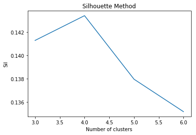

```python
# running and plotting silhouette analysis
from sklearn.metrics import silhouette_score

sil = []


for k in range(3, 7):
  kmeans = KMeans(n_clusters = k).fit(x)
  preds = kmeans.fit_predict(x)
  sil.append(silhouette_score(x, preds, metric = 'euclidean'))


plt.plot(range(3, 7), sil)
plt.title('Silhouette Method')
plt.xlabel('Number of clusters')
plt.ylabel('Sil')
plt.show()
```

Analysis above shows that optimal cluster size is 4.

# 6. Clusters creation

In this section I will create cluster and try to describe their properities.

As mentioned above, 4 clusters are choosen based on the elbow chart. To detrmine number of clusters I used Elbow method. I also confirmed it with other technique called silhouette analysis.Now, using K-Means I will do classification of data to 4 clusters.

```python
# Create 4 clusters
km = KMeans(n_clusters =4, init = 'k-means++', max_iter =300, n_init =10, random_state = 42)
y_km = km.fit_predict(x)
```

```python
# Create cluster dataframe
cluster = pd.DataFrame(y_km).set_index(dffinal_temp.index)
```

```python
# Merge cluster identifier
cluster.columns = ['cluster']
dffinal_clustered = pd.merge(dffinal_temp, cluster, on='person')
customer_clustered = pd.merge(final_df, cluster, on='person')
```

In the section below I will create plots that will help to better describe 4 clusters.

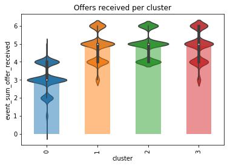

```python
# Plot of offers received
ax = sns.violinplot(x="cluster", y="event_sum_offer_received", data=dffinal_clustered)

dffinal_clustered.groupby('cluster')['event_sum_offer_received'].mean().plot(kind='bar' , title = 'Offers received per cluster',alpha = 0.5);
```

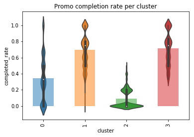

```python
# Plot of completition rate
ax = sns.violinplot(x="cluster", y='completed_rate', data=dffinal_clustered)

dffinal_clustered.groupby('cluster')['completed_rate'].mean().plot(kind='bar' , title = 'Promo completion rate per cluster',alpha = 0.5);
```

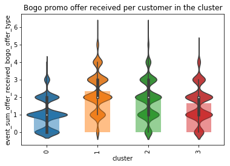

```python
# Plot of bogo offers received
ax = sns.violinplot(x="cluster", y="event_sum_offer_received_bogo_offer_type", data=dffinal_clustered);
dffinal_clustered.groupby('cluster')['event_sum_offer_received_bogo_offer_type'].mean().plot(kind='bar' , title = 'Bogo promo offer received per customer in the cluster',alpha = 0.5);
```

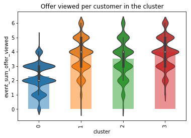

```python
# Plot of offers viewed
ax = sns.violinplot(x="cluster", y="event_sum_offer_viewed", data=dffinal_clustered)
dffinal_clustered.groupby('cluster')['event_sum_offer_viewed'].mean().plot(kind='bar' , title = 'Offer viewed per customer in the cluster',alpha = 0.5);
```

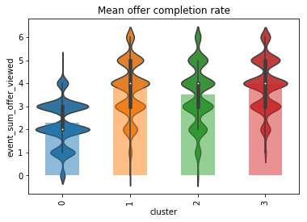

```python
# Plot of bogo offers viewed
ax = sns.violinplot(x="cluster", y="event_sum_offer_viewed", data=dffinal_clustered)

dffinal_clustered.groupby('cluster')['event_sum_offer_viewed'].mean().plot(kind='bar' , title = 'Mean offer completion rate',alpha = 0.5);
```

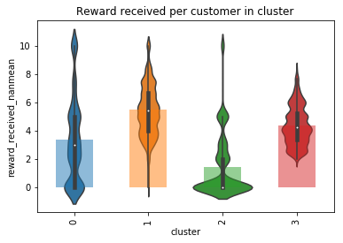

```python
# Plot of rewards received
ax = sns.violinplot(x="cluster", y="reward_received_nanmean", data=dffinal_clustered)

dffinal_clustered.groupby('cluster')['reward_received_nanmean'].mean().plot(kind='bar' , title = 'Reward received per customer in cluster',alpha = 0.5);
```

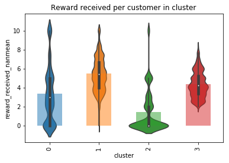

```python
# Plot of rewards received
ax = sns.violinplot(x="cluster", y="reward_received_nanmean", data=dffinal_clustered)

dffinal_clustered.groupby('cluster')['reward_received_nanmean'].mean().plot(kind='bar' , title = 'Reward received per customer in cluster',alpha = 0.5);
```

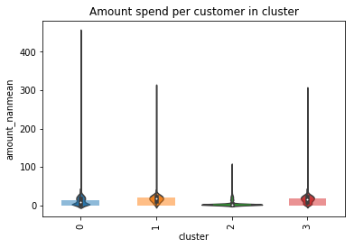

```python
# Plot of amount spend
ax = sns.violinplot(x="cluster", y="amount_nanmean", data=dffinal_clustered)

dffinal_clustered.groupby('cluster')['amount_nanmean'].mean().plot(kind='bar' , title = 'Amount spend per customer in cluster',alpha = 0.5);
```

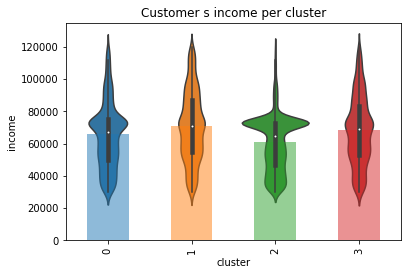

```python
# Plot of customer income
ax = sns.violinplot(x="cluster", y="income", data=dffinal_clustered)

dffinal_clustered.groupby('cluster')['income'].mean().plot(kind='bar' , title = 'Customer s income per cluster',alpha = 0.5);
```

Plots above help to determine basic description of cluster that is presetnted below.

**Cluster 0**

**Cluster 1**

Customer in this cluster received high number of offers (on avg. 4.8) that is comparable to clusters 2 and 3. Average response to these offers is moderate (69%). These customers spend the highest amount on orders across all groups (19.9 avg). They also receive the highest reward 5.45 on average that gives reward to spend ratio of 0.27. Avg. income of customer in this group is 71098 that is the highest. To demonstrate the potential of this group I calculate spend to income ratio (spend on orders multiplied by 1000 and outcome of this divided by income). Spend to income ratio is 0.28.

**Cluster 2**

**Cluster 3**

Customers in this cluster received the highest number of offers (on avg. 4.9) that is comparable to clusters 2 and 3. Average response to these offers is moderate (72%). Customers spend on average 17.66 per order. Avg reward they collect is 4.38 that gives 0.25 reward to spend ratio. Avg.income of customers in this group is 68477 that is relatively high.To demonstrate potential of this group I calculate spend to income ratio (spend on orders multiplied by 1000 and outcome of this divided by income). Spend to income ratio is 0.26.

In the next section additional plots will be presented to review clusters based on other attributes.

Gender

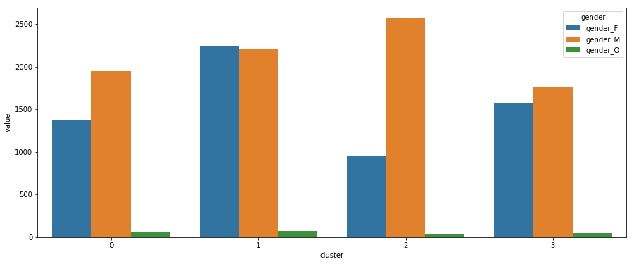

```python
# Demography profile- Gender
channel_rate = dffinal_clustered[['cluster','gender_F','gender_M','gender_O',]].groupby(['cluster']).sum()
channel_rate_stack = pd.DataFrame(channel_rate.stack()).reset_index()
channel_rate_stack.columns=['cluster','gender','value']

f, ax = plt.subplots(figsize=(15, 6))
ax = sns.barplot(x="cluster", y="value", hue='gender', data=channel_rate_stack)
```

Age

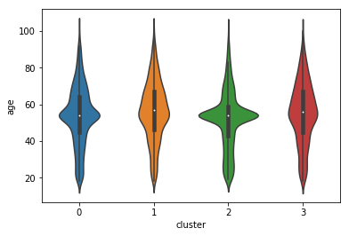

```python
# Demography profile- Age plotting
ax = sns.violinplot(x="cluster", y="age", data=dffinal_clustered)
```

Channels

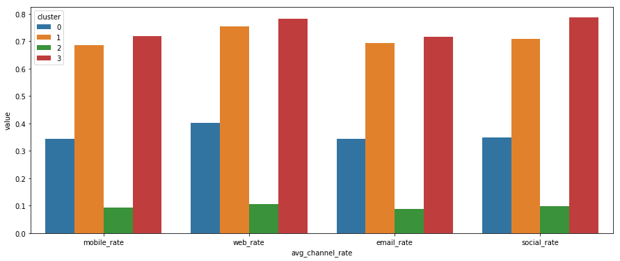

```python
# By channel analysis
channel_rate = dffinal_clustered[['mobile_rate','web_rate','email_rate','social_rate','cluster']].groupby(['cluster']).mean()
channel_rate_stack = pd.DataFrame(channel_rate.stack()).reset_index()
channel_rate_stack.columns=['cluster','avg_channel_rate','value']

f, ax = plt.subplots(figsize=(15, 6))
ax = sns.barplot(x="avg_channel_rate", y="value", hue='cluster', data=channel_rate_stack)
```

Reward

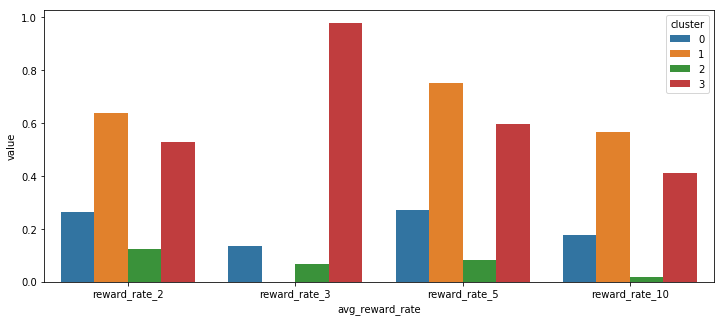

```python
# By reward analysis
channel_rate = dffinal_clustered[['cluster','reward_rate_2','reward_rate_3','reward_rate_5','reward_rate_10',]].groupby(['cluster']).mean()
channel_rate_stack = pd.DataFrame(channel_rate.stack()).reset_index()
channel_rate_stack.columns=['cluster','avg_reward_rate','value']

f, ax = plt.subplots(figsize=(12, 5))
ax = sns.barplot(x="avg_reward_rate", y="value", hue='cluster', data=channel_rate_stack)
```

# 7. Conclusion

In this section I will summarize findings on clusters and make some recomendations.

## 7.1. Clusters

In the previous point I have plotted multiple attributes for clusters. These plots helped to update cluster descriptions so I can also share recommendations.

**Cluster 0**

**Cluster 1**

Customer in this cluster received high number of offers (on avg. 4.8) that is comparable to clusters 2 and 3. Average response to these offer is moderate (69%). These customers spend the highest amount on orders across all groups (19.9 avg). They also receive the highest reward 5.45 on average that gives reward to spend ratio of 0.27. Avg. income of customer in this group is 71098 that is the highest. To demonstrate potential of this group I calulate spend to income ratio (spend on orders multipled by 1000 and ouutcome of this divided by income). Spend to income ratio is 0.28. This cluster also presents almost equal split between Females and Males. This cluster seems to collect the most enaged customers based on the amount they spend on orders. While their response to offer is moderate marketing should focus action on the long term engagement.

**Cluster 2**

**Cluster 3**

Customer in this cluster received the highest high number of offers (on avg. 4.9) that is comparable to clusters 2 and 3. Average response to these offer is moderate (72%). Customers spend on average 17.66 per order. Avg reward they collect is 4.38 that gives 0.25 reward to spend ratio. Avg. income of customer in this group is 68477 that is relatively high.To demonstrate potential of this group I calulate spend to income ratio (spend on orders multipled by 1000 and ouutcome of this divided by income). Spend to income ratio is 0.26. Any offers should focus on keeping current performance as based on the metrics it is recommended to ensure current behaviors/performance is kept.

## 7.2. Reflection

In this exercise I have created 4 cohorts to segment Starbucks’ customers. Cohorting is the common approach when it comes to finding patterns or characteristics related to customers behaviour. Cohorting allows companies to group customers and based on characteristics of cohort classify customers in order to better tailor marketing, engagement or other activities.

When executing this exercise I have followed the CRISP - DM process. This process required several steps:

1. Setting goals.
2. Data Wrangling ( incl. steps like gathering, assessing, cleaning data, and enriching data).
3. Modeling parameters.
4. Evaluation.
5. Deployment.
6. Insights sharing.

In the first step (Setting goals) I have defined 2 business insights I want to deliver. Through step 2 I have executed multiple operations on data to prepare a dataset for modeling parameters.

In the final step, I have clustered data using KMeans method and created visualizations that helped me to answer business questions defined in this project.